# Ejercicio de regresion lineal multiple

# Introduccion

En este ejemplo trabajaremos con el dataset Boston del paquete MASS. El objetivo del problema es predecir el valor de la vivienda en funcion de las variables del fichero.

**Objetivo:** El objetivo del problema es predecir el valor de la vivienda en funcion de las variables del fichero.

Este dataset Boston recoge la media del valor de la vivienda en 506 areas residenciales de Boston. Junto con el precio, se han registrado 13 variables adicionales.

- crim: ratio de criminalidad per capita de cada ciudad.
- zn: Proporcion de zonas residenciales con edificaciones de mas de 25.000 pies cuadrados.
- indus: proporcion de zona industrializada.
- chas: Si hay rio en la ciudad (= 1 si hay rio; 0 no hay).
- nox: Concentracion de oxidos de nitrogeno (partes per 10 millon).
- rm: promedio de habitaciones por vivienda.
- age: Proporcion de viviendas ocupadas por el propietario construidas antes de 1940.
- dis: Media ponderada de la distancias a cinco centros de empleo de Boston.
- rad: Indice de accesibilidad a las autopistas radiales.
- tax: Tasa de impuesto a la propiedad en unidades de $10,000.
- ptratio: ratio de alumnos/profesor por ciudad.
- black: 1000(Bk - 0.63)^2 donde Bk es la proporcion de gente de color por ciudad.
- lstat: porcentaje de poblacion en condicion de pobreza.
- medv: Valor medio de las casas ocupadas por el dueno en unidades de $1000s.

Primero comenzaremos por cargar los paquetes necesarios.

```r
library(MASS)
library(ISLR)
library(psych)
library(caret)
library (ggplot2)
library(DMwR)  # para usar la funcion regr.eval
library(stats)
```

A continuacion, cargamos el dataset y visualizamos sus primeros elementos. tambien identificamos el numero de filas y columnas.

```r
# Carga el dataset
data("Boston")

# Muestra las primeras filas del dataset
head (Boston)
```

|  | crim | zn | indus | chas | nox | rm | age | dis | rad | tax | ptratio | black | lstat | medv |
| --- | --- | --- | --- | --- | --- | --- | --- | --- | --- | --- | --- | --- | --- | --- |
| 1 | 0.00632 | 18 | 2.31 | 0 | 0.538 | 6.575 | 65.2 | 4.0900 | 1 | 296 | 15.3 | 396.90 | 4.98 | 24.0 |
| 2 | 0.02731 | 0 | 7.07 | 0 | 0.469 | 6.421 | 78.9 | 4.9671 | 2 | 242 | 17.8 | 396.90 | 9.14 | 21.6 |
| 3 | 0.02729 | 0 | 7.07 | 0 | 0.469 | 7.185 | 61.1 | 4.9671 | 2 | 242 | 17.8 | 392.83 | 4.03 | 34.7 |
| 4 | 0.03237 | 0 | 2.18 | 0 | 0.458 | 6.998 | 45.8 | 6.0622 | 3 | 222 | 18.7 | 394.63 | 2.94 | 33.4 |
| 5 | 0.06905 | 0 | 2.18 | 0 | 0.458 | 7.147 | 54.2 | 6.0622 | 3 | 222 | 18.7 | 396.90 | 5.33 | 36.2 |
| 6 | 0.02985 | 0 | 2.18 | 0 | 0.458 | 6.430 | 58.7 | 6.0622 | 3 | 222 | 18.7 | 394.12 | 5.21 | 28.7 |

```r
# numero de filas y columnas
nrow(Boston)
```

```
[1] 506
```

```r
ncol(Boston)
```

```
[1] 14
```

# Analisis exploratorio

En primer lugar se realiza un analisis basico de los datos de forma numerica y grafica. Usaremos la funcion **summary** que cuando se aplica a una variable presenta un pequeno resumen descriptivo. Si la variable es numerica, dicho resumen incluye el manimo, maximo, mediana, primer y tercer cuartiles, media y numero de valores perdidos. Si la variable es de tipo factor, **summary()** muestra el numero de observaciones en cada nivel del factor:

```r
summary(Boston)
```

```
      crim                zn             indus            chas              nox
 Min.   : 0.00632   Min.   :  0.00   Min.   : 0.46   Min.   :0.00000   Min.   :0.3850
 1st Qu.: 0.08204   1st Qu.:  0.00   1st Qu.: 5.19   1st Qu.:0.00000   1st Qu.:0.4490
 Median : 0.25651   Median :  0.00   Median : 9.69   Median :0.00000   Median :0.5380
 Mean   : 3.61352   Mean   : 11.36   Mean   :11.14   Mean   :0.06917   Mean   :0.5547
 3rd Qu.: 3.67708   3rd Qu.: 12.50   3rd Qu.:18.10   3rd Qu.:0.00000   3rd Qu.:0.6240
 Max.   :88.97620   Max.   :100.00   Max.   :27.74   Max.   :1.00000   Max.   :0.8710
       rm             age              dis              rad              tax           ptratio
 Min.   :3.561   Min.   :  2.90   Min.   : 1.130   Min.   : 1.000   Min.   :187.0   Min.   :12.60
 1st Qu.:5.886   1st Qu.: 45.02   1st Qu.: 2.100   1st Qu.: 4.000   1st Qu.:279.0   1st Qu.:17.40
 Median :6.208   Median : 77.50   Median : 3.207   Median : 5.000   Median :330.0   Median :19.05
 Mean   :6.285   Mean   : 68.57   Mean   : 3.795   Mean   : 9.549   Mean   :408.2   Mean   :18.46
 3rd Qu.:6.623   3rd Qu.: 94.08   3rd Qu.: 5.188   3rd Qu.:24.000   3rd Qu.:666.0   3rd Qu.:20.20
 Max.   :8.780   Max.   :100.00   Max.   :12.127   Max.   :24.000   Max.   :711.0   Max.   :22.00
     black            lstat            medv
 Min.   :  0.32   Min.   : 1.73   Min.   : 5.00
 1st Qu.:375.38   1st Qu.: 6.95   1st Qu.:17.02
 Median :391.44   Median :11.36   Median :21.20
 Mean   :356.67   Mean   :12.65   Mean   :22.53
 3rd Qu.:396.23   3rd Qu.:16.95   3rd Qu.:25.00
 Max.   :396.90   Max.   :37.97   Max.   :50.00
```

Tambien comprobaremos que no existen valores ausentes (NA) con la funcion **any(is.na(dataset))**.

```r
any(is.na(Boston))
```

```
[1] FALSE
```

```r
# Podemos contar los elementos ausentes
sum(is.na(Boston$medv))
```

```
[1] 0
```

```r
#Si los hay, podemos omitirlos de la siguiente manera:
dataBoston <- na.omit(Boston)
```

El primer paso a la hora de establecer un modelo lineal múltiple es estudiar la relación que existe entre variables. Esta información es crítica a la hora de identificar cuáles pueden ser los mejores predictores para el modelo, qué variables presentan relaciones de tipo no lineal (por lo que no pueden ser incluidas) y para identificar colinialidad entre predictores. A modo complementario, es recomendable representar la distribución de cada variable mediante histogramas.

Usaremos la función *multi.hist*, dibujando en rojo la curva normal y en azul la función de densidad.

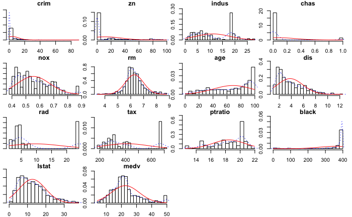

```r
library(psych)
multi.hist(x = Boston, dcol = c("blue", "red"), dlty = c("dotted", "solid"))
```

# Dividir el data set:entrenamiento y test

Ahora se divide el conjunto de datos en dos subconjuntos:

1. Conjunto de entrenamiento: Un subconjunto para entrenar un modelo (80% de los datos)
2. Conjunto de prueba: Un subconjunto para probar el modelo entrenado (20% de los datos)

```r
set.seed(123)
# create a list of 80% of the rows in the original dataset we can use for training
validation_index <- createDataPartition(Boston$medv, p=0.80, list=FALSE)
# select 20% of the data for validation
testBoston <- Boston[-validation_index,]
# use the remaining 80% of data to training and testing the models
trainBoston <- Boston[validation_index,]
```

# Modelo de regresión multiple

Se quiere generar un modelo que permita explicar el precio de la vivienda de una población empleando para ello cualquiera de las variables disponibles en el dataset Boston y que resulten útiles en el modelo.

R permite crear un modelo con todas las variables incluidas en un data.frame de la siguiente forma:

```r
modeloRegMultiple <- lm(formula = medv ~ ., data = trainBoston)
# Tambienn se pueden especificar una a una
summary(modeloRegMultiple)
```

```
Call:
lm(formula = medv ~ ., data = trainBoston)

Residuals:
     Min       1Q   Median       3Q      Max
-14.9550  -2.7996  -0.4647   1.7767  25.0993

Coefficients:
              Estimate Std. Error t value Pr(>|t|)
(Intercept)  37.733617   5.619935   6.714 6.63e-11 ***
crim         -0.093857   0.039157  -2.397 0.016999 *
zn            0.039436   0.015987   2.467 0.014062 *
indus        -0.012988   0.069595  -0.187 0.852059
chas          2.290187   0.940621   2.435 0.015346 *
nox         -17.130560   4.342272  -3.945 9.45e-05 ***
rm            3.499219   0.451445   7.751 7.87e-14 ***
age           0.009823   0.015510   0.633 0.526905
dis          -1.390769   0.230614  -6.031 3.77e-09 ***
rad           0.330939   0.077135   4.290 2.25e-05 ***
tax          -0.012386   0.004342  -2.852 0.004568 **
ptratio      -0.960676   0.150307  -6.391 4.66e-10 ***
black         0.009841   0.002935   3.353 0.000877 ***
lstat        -0.562095   0.059180  -9.498  < 2e-16 ***
---
Signif. codes:  0 ‘***’ 0.001 ‘**’ 0.01 ‘*’ 0.05 ‘.’ 0.1 ‘ ’ 1

Residual standard error: 4.801 on 393 degrees of freedom
Multiple R-squared:  0.7346,    Adjusted R-squared:  0.7258
F-statistic: 83.68 on 13 and 393 DF,  p-value: < 2.2e-16
```

El *p-value* obtenido para el estadístico F es muy pequeño (< 2.2e-16) lo que indica que al menos uno de los predictores introducidos en el modelo está relacionado con la variable respuesta *medv*. El modelo es capaz de explicar el 72,5% de la variabilidad observada en el precio de la vivienda (*R^2*=0.7258). El R-cuadrado ajustado (Adjusted R-squared) es el parametro que se debe usar con modelos de más de una variable, ya que R-cuadrado puede aumentar a medida que se agregan predictores al modelo de regresión. Sin embargo, este aumento es artificial cuando los predictores no mejoran el ajuste del modelo.

En el summary se puede observar que algunos predictores tienen p-values muy altos, sugiriendo que no contribuyen al modelo por lo que deben ser excluidos, por ejemplo *age* e *indus*.

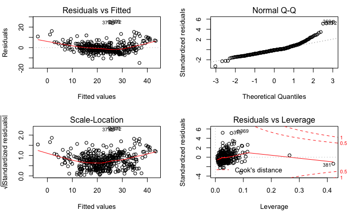

```r
par(mfrow = c(2,2))
plot(modeloRegMultiple)
```

Ahora predecimos los valores de medv para los datos guardados en el data set de test.

```r
prediccionRegMult<-predict(object=modeloRegMultiple, newdata=testBoston, level=0.95)

print(prediccionRegMult)
```

```
        3         6         9        11        14        15        31        32        36        41
30.604064 25.730720 11.537482 19.109253 19.839532 19.627393 11.521988 18.432404 24.078325 33.611587
       45        51        54        74        76        78        79        82        86        92
23.005905 21.304142 24.026476 23.634731 23.754810 23.114795 21.063635 27.121906 27.908539 27.628241
      105       108       109       111       120       127       130       131       138       142
21.552408 20.742873 22.739767 20.438710 20.814271 13.745106 13.720802 19.701069 18.926693  3.259046
      146       151       152       155       163       167       168       170       172       178
11.410819 20.815324 18.535045 21.874370 39.957003 36.867382 22.872758 26.502257 24.312443 29.542839
      182       184       188       198       203       205       215       218       221       224
27.929020 31.493002 33.080641 32.136541 36.285169 42.275414 10.084962 28.344393 32.963007 30.074281
      244       246       247       250       252       255       257       262       271       293
27.264121 13.696650 20.193977 23.986545 25.023220 23.833579 36.840137 37.190700 22.080228 31.201997
      294       300       305       307       312       316       320       323       326       330
25.483065 31.452150 32.915669 35.433855 26.907261 20.821038 21.269860 23.070923 24.579500 24.211498
      348       352       355       357       370       378       393       394       401       403
24.950623 20.723942 14.387980 19.609837 32.781438 20.192437 10.292981 20.571698 12.145365 18.411383
      405       406       410       411       417       422       445       449       453       455
 7.826837  9.297711 19.772054 16.265083 12.946973 18.496985 11.700020 17.878765 18.819675 15.224040
      472       481       484       486       487       490       493       495       496
23.327466 23.710823 21.276806 22.377392 19.955935  7.512912 15.361866 20.367432 16.476180
```

En la variable que ha devuelto el metodo *predict* se guardan los valores que se han predicho utilizando el modelo de predicción creado. Nos interesa compararlos con los valores que tenemos en el data set *testBoston* para ver la fiabilidad de nuestro modelo.

Vamos a calcular el training error rate y el test error rate.

- **Training error rate**: error que comete el modelo al predecir observaciones que pertenecen al training data set.
- **Test error rate**: error que comete el modelo al predecir observaciones de un data set de test y que por lo tanto el modelo no ha “visto”.

Creamos un data frame con los valores predichos con el modelo y los valores que teníamos en el data set de test.

```r
comparativa<-data.frame(cbind(actuals=testBoston$medv, predicted=prediccionRegMult))
comparativa
```

[output not shown]

Se calculan los errores que se están cometiendo al realizar las predicciones utilizando la función *regr.eval* que recibe como argumento de entrada los valores observados y los valores obtenidos con el modelo de predicción:

```r
# Error en el test
testErrors<-regr.eval(comparativa$actuals, comparativa$predicted)
testErrors
```

[output not shown]

Tambien vamos a calcular el training error rate:

```r
#Error en las predicciones realizadas con el data set train
prediccionRegMultTrain<-predict(object=modeloRegMultiple, newdata=trainBoston, level=0.95)

comparativaTrain<-data.frame(cbind(actuals=trainBoston$medv, predicted=prediccionRegMultTrain))
comparativaTrain

trainErrors<-regr.eval(comparativaTrain$actuals, comparativaTrain$predicted)
trainErrors
```

[output not shown]

Al comparar los errores, vemos que el training error rate es inferior al test error rate, como era de esperar. También nos fijamos que las diferencias entre los dos errores no son muy elevadas. EStamos descartando un posible overfitting de nuestro modelo.

```r
#Error en el train
trainErrors<-regr.eval(comparativaTrain$actuals, comparativaTrain$predicted)
trainErrors
# Error en el test
testErrors<-regr.eval(comparativa$actuals, comparativa$predicted)
testErrors
```

[output not shown]

## Correlación y multicolinealidad

En los modelos de regresión lineal con múltiples predictores, además del estudio de los residuos vistos en el modelo simple, es necesario descartar colinealidad o multicolinealidad entre variables.

En el modelo de regresión que incluye todas las variables del data set hemos detectado que hay algunos predictores que tienen p-values muy altos, sugiriendo que no contribuyen al modelo por lo que deben ser excluidos, por ejemplo *age* e *indus*.

Para identificar qué variables son representativas para el modelo vamos a analizar la correlación y multicolinealidad.

Vamos a crear la matriz de correlacion que mide la fuerza y la direccion de las relaciones entre las variables. Los valores que puede tomar siempre se encuentran comprendidos entre +1 o -1.

- Cuando r = -1, existe una relacion lineal perfecta negativa.
- Si r esta proximo a -1, existe una relacion lineal negativa muy fuerte.
- Cuando r esta proximo a 0, significa que no hay una relacion lineal.
- Si r esta proximo a +1, existe una relacion lineal positiva muy fuerte.
- Cuando r = +1, existe una relacion lineal perfecta positiva.

```r
correlacion<-round(cor(Boston), 1)

library(corrplot)
corrplot(correlacion, method="number", type="lower")
```

[output not shown]

**Observaciones:**

- Para aplicar el modelo de regresion lineal, seleccionaremos las variables que tengan un indice alto de correlacion con nuestra variable objetivo (medv). En este caso, se observa que *rm* (numero de habitaciones) tiene un correlacion positiva alta con medv (0.7) y *lstat* (porcentaje de poblacion en condicion de pobreza) tiene una correlacion negativa alta con medv (-0.7).
- Un aspecto importante a la hora de elegir las variables para el modelo de regresion es analizar la multicolinealidad. La multicolinealidad en regresion es una condicion que ocurre cuando algunas variables predictoras incluidas en el modelo estan correlacionadas con otras variables predictoras. Las caracteristicas *rad* (indice de accesibilidad a las autopistas radiales), *tax* (Tasa de impuesto a la propiedad en unidades de $10,000) tiene una correlacion de 0.9, lo que implica que estan fuertemente correladas. No deberiamos seleccionar estas dos caracteristicas juntas a la hora de entrenar el modelo. Lo mismo ocurre con *dis* (Media ponderada de la distancias a cinco centros de empleo de Boston) y *age* (Proporcion de viviendas ocupadas por el propietario construidas antes de 1940), que tienen una correlacion de -0.7.

Por lo tanto, podríamos crear otro modelo eliminando las siguientes variables:

- *indus* y *age* porque en el análisis del modelo completo han obtenido una p>=0.05.
- *tax* porque hemos visto que tiene una correlación de 0.9 con *rad*. Elegimos una de las dos.

## Modelo 2

```r
modeloRegMultiple2 <- lm(formula = medv ~ crim+chas+nox+rm+dis+ptratio+rad+black+lstat, data = trainBoston)

summary(modeloRegMultiple2)
```

[output not shown]

Usamos el data set de test para predecir:

```r
prediccionRegMult2=predict(object=modeloRegMultiple2, newdata=testBoston, level=0.95)

print(prediccionRegMult2)
```

[output not shown]

Se calculan los errores cometidos en la predicción:

```r
comparativa2=data.frame(cbind(varlstat=testBoston$lstat, actuals=testBoston$medv, predicted=prediccionRegMult2))

testErrorsMod2<-regr.eval(comparativa2$actuals, comparativa2$predicted)
testErrorsMod2
```

[output not shown]

Y los comparo con el modelo anterior:

```r
testErrorsMod1<-regr.eval(comparativa$actuals, comparativa$predicted)
testErrorsMod1
```

[output not shown]

Tambien vamos a calcular el training error rate:

```r
#Error en las predicciones realizadas con el data set train
prediccionRegMultTrain2<-predict(object=modeloRegMultiple2, newdata=trainBoston, level=0.95)

comparativaTrainMod2<-data.frame(cbind(actuals=trainBoston$medv, predicted=prediccionRegMultTrain2))
comparativaTrainMod2

trainErrorsMod2<-regr.eval(comparativaTrainMod2$actuals, comparativaTrainMod2$predicted)
trainErrorsMod2
trainErrors  # train error modelo 1
```

[output not shown]

Al comparar los errores, vemos que el training error rate es inferior al test error rate, como era de esperar. También nos fijamos que las diferencias entre los dos errores no son muy elevadas. EStamos descartando un posible overfitting de nuestro modelo.

```r
#Error en el train y test
trainErrorsMod2
testErrorsMod2
```

[output not shown]

# Conclusion

Se han propuesto dos modelos de regresión múltiple, el primero con todas las variables del data set (modelo 1 contiene 13 variables) y el segundo modelo que tiene en cuenta 9 variables (modelo 2).

En relación con los modelos obtenidos y teniendo en cuenta el parámetro R^2, el modelo 1 tiene un R^2 de 0,7258 y el modelo 2 de 0,7192. Son muy parecidos. en este caso, habría que valorar si merece la pena tener un modelo de 9 o 13 variables. Cuantas más variables tengamos en nuestro modelo mayor será la complejidad del propio modelo como la de recopilar información sobre esas variables.

En cuento a las medidas de error, vemos que son muy similares. En base a estos resultados, sería preferible quedarse con el modelo de 9 variables.